# Beam-scan raster: HFSS beam against a uniform sky and the canyon terrain

## 3. Terrain fraction and antenna temperature

```python
F_TERRAIN = np.array([POWER @ terrain_mask(a, e) for a, e in zip(AZ, EL)])     # (time, 51)
T_HFSS = T_SKY * (1 - F_TERRAIN) + T_TERRAIN * F_TERRAIN                     # K, at HFSS frequencies
T_ANT = np.array([np.interp(FREQ, HFSS_FREQS, row, left=np.nan, right=np.nan) for row in T_HFSS])  # (time, 1024)
print('terrain fraction: min %.3f  median %.3f  max %.3f' % (F_TERRAIN.min(), np.median(F_TERRAIN), F_TERRAIN.max()))
print('T_ant [K]: min %.1f  median %.1f  max %.1f' % (T_HFSS.min(), np.median(T_HFSS), T_HFSS.max()))

# Sanity: pointing at zenith with the front/back-symmetric beam, about half the power is below the horizon.
print('zenith pointing, 150 MHz terrain fraction: %.3f' % (POWER[k150] @ terrain_mask(0.0, 0.0)))
```

```
terrain fraction: min 0.461  median 0.660  max 0.758
T_ant [K]: min 469.5  median 537.7  max 677.5
zenith pointing, 150 MHz terrain fraction: 0.559
```

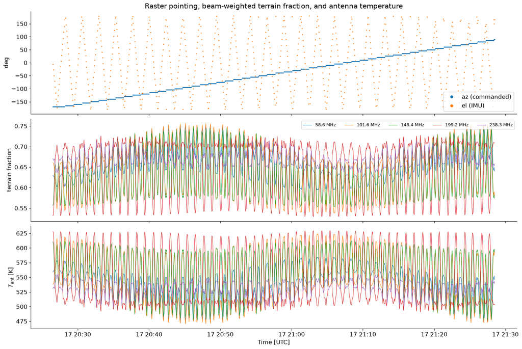

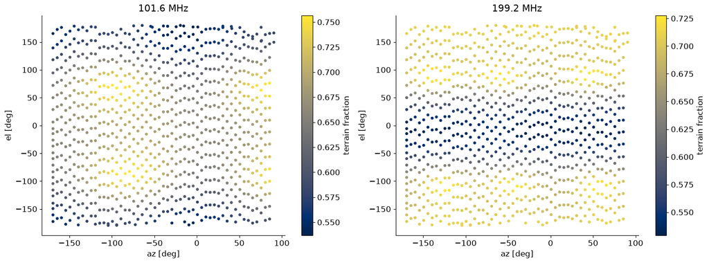

```python
tnum = mdates.date2num(TIME.tz_localize(None))
fig, axes = plt.subplots(3, 1, figsize=(15, 10), sharex=True, constrained_layout=True)
axes[0].plot(TIME, (AZ + 180) % 360 - 180, '.', ms=2, label='az (commanded)')
axes[0].plot(TIME, EL, '.', ms=2, label='el (IMU)')
axes[0].set_ylabel('deg'); axes[0].legend(markerscale=5)
for mhz in (60, 100, 150, 200, 240):
    k = int(np.argmin(abs(HFSS_FREQS - mhz)))
    axes[1].plot(TIME, F_TERRAIN[:, k], lw=0.8, label='%.1f MHz' % HFSS_FREQS[k])
    axes[2].plot(TIME, T_HFSS[:, k], lw=0.8)
axes[1].set_ylabel('terrain fraction'); axes[1].legend(fontsize=9, ncol=5)
axes[2].set_ylabel(r'$T_\mathrm{ant}$ [K]'); axes[2].set_xlabel('Time [UTC]')
axes[0].set_title('Raster pointing, beam-weighted terrain fraction, and antenna temperature')
plt.show()

fig, axes = plt.subplots(1, 2, figsize=(15, 5.5), constrained_layout=True)
for ax, mhz in zip(axes, (100, 200)):
    k = int(np.argmin(abs(HFSS_FREQS - mhz)))
    sc = ax.scatter((AZ + 180) % 360 - 180, EL, c=F_TERRAIN[:, k], s=12, cmap='cividis')
    fig.colorbar(sc, ax=ax, label='terrain fraction')
    ax.set_xlabel('az [deg]'); ax.set_ylabel('el [deg]'); ax.set_title('%.1f MHz' % HFSS_FREQS[k])
plt.show()
```

## 4. Data against the model

Correlator counts include receiver gain and noise, and the transmitter's broadband noise during the raster, so the comparison is of time variation only. No gain or offset is fitted. Tooth channels (index % 8 in {7, 0, 1}) are excluded because the transmitter comb dominates them. Samples carrying an RFI bit are masked. Rows from 20:54 onward have no flags (§1). The correlations are computed on flagged rows only, and again on all rows.

[output not shown]

[figure not shown]

```python
fig, axes = plt.subplots(nrows=2, sharex=True)
axes[0].plot(TIME, (AZ + 180) % 360 - 180, '-', ms=2, label='az (commanded)')
axes[0].plot(TIME, EL, '-', ms=2, label='el (IMU)')
axes[1].plot(TIME, D[:, ch_tx])
axes[1].plot(TIME, D[:, ch])
#axes[1].plot(TIME, 2.1e3 * T_ANT[:, ch] - 0.5e5)
#axes[1].plot(TIME, 0.3e3 * T_ANT[:, ch] + 0.3e5)
#axes[1].plot(TIME, 1.3e2 * T_ANT[:, ch] + 0.3e5)
axes[1].plot(TIME, 3.3e2 * T_ANT[:, ch] + 2.3e5)
```

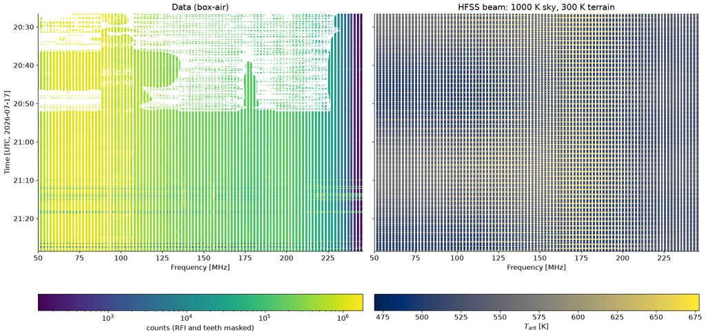

```python
TEETH = np.abs((np.arange(1024) + 4) % 8 - 4) <= 1
use_ch = band & ~TEETH
Dm = np.where(RFI | ~use_ch[None, :], np.nan, D)
fig, axes = plt.subplots(1, 2, figsize=(17, 8), sharey=True, sharex=True, constrained_layout=True)
lo, hi = np.nanpercentile(Dm[:, use_ch], [2, 98])
m0 = axes[0].pcolormesh(FREQ, tnum, np.ma.masked_invalid(Dm), shading='nearest', norm=LogNorm(lo, hi), rasterized=True)
fig.colorbar(m0, ax=axes[0], orientation='horizontal', pad=0.08, label='counts (RFI and teeth masked)')
m1 = axes[1].pcolormesh(FREQ, tnum, np.ma.masked_invalid(np.where(use_ch[None, :], T_ANT, np.nan)),
                        shading='nearest', cmap='cividis', rasterized=True)
fig.colorbar(m1, ax=axes[1], orientation='horizontal', pad=0.08, label=r'$T_\mathrm{ant}$ [K]')
for ax, title in zip(axes, ('Data (box-air)', 'HFSS beam: 1000 K sky, 300 K terrain')):
    ax.set_xlabel('Frequency [MHz]'); ax.set_title(title); ax.set_xlim(50, 246)
axes[0].yaxis_date(); axes[0].yaxis.set_major_formatter(mdates.DateFormatter('%H:%M')); axes[0].invert_yaxis()
axes[0].set_ylabel('Time [UTC, 2026-07-17]')
plt.show()
```

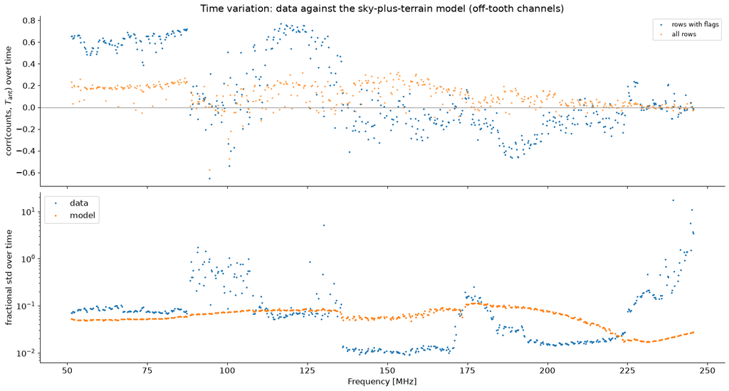

| band | r | r_all_rows | data_frac_std | model_frac_std |
| --- | --- | --- | --- | --- |
| (50, 87] | 0.629 | 0.184 | 0.079 | 0.052 |
| (87, 108] | 0.044 | 0.032 | 0.487 | 0.071 |
| (108, 140] | 0.548 | 0.137 | 0.068 | 0.080 |
| (140, 190] | -0.129 | 0.152 | 0.013 | 0.078 |
| (190, 246] | -0.074 | 0.023 | 0.022 | 0.032 |

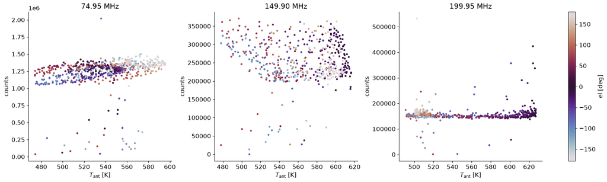

```python
# Per channel: correlation over time between counts and T_ant, on unflagged samples.
rows = []
for c in np.flatnonzero(use_ch):
    ok = np.isfinite(Dm[:, c]) & np.isfinite(T_ANT[:, c]) & HAS_FLAGS
    ok_all = np.isfinite(Dm[:, c]) & np.isfinite(T_ANT[:, c])
    if ok.sum() < 50:
        continue
    rows.append(dict(channel=c, freq_mhz=FREQ[c], n=int(ok.sum()),
                     r=np.corrcoef(Dm[ok, c], T_ANT[ok, c])[0, 1],
                     r_all_rows=np.corrcoef(Dm[ok_all, c], T_ANT[ok_all, c])[0, 1],
                     data_frac_std=np.std(Dm[ok, c]) / np.mean(Dm[ok, c]),
                     model_frac_std=np.std(T_ANT[ok, c]) / np.mean(T_ANT[ok, c])))
CORR = pd.DataFrame(rows)
fig, axes = plt.subplots(2, 1, figsize=(15, 8), sharex=True, constrained_layout=True)
axes[0].plot(CORR.freq_mhz, CORR.r, '.', ms=3, label='rows with flags')
axes[0].plot(CORR.freq_mhz, CORR.r_all_rows, '.', ms=3, alpha=0.6, label='all rows')
axes[0].legend(fontsize=9)
axes[0].axhline(0, color='0.6', lw=1); axes[0].set_ylabel('corr(counts, $T_\\mathrm{ant}$) over time')
axes[1].semilogy(CORR.freq_mhz, CORR.data_frac_std, '.', ms=3, label='data')
axes[1].semilogy(CORR.freq_mhz, CORR.model_frac_std, '.', ms=3, label='model')
axes[1].set_ylabel('fractional std over time'); axes[1].set_xlabel('Frequency [MHz]'); axes[1].legend()
axes[0].set_title('Time variation: data against the sky-plus-terrain model (off-tooth channels)')
plt.show()
display(CORR.assign(band=pd.cut(CORR.freq_mhz, [50, 87, 108, 140, 190, 246]))
        .groupby('band', observed=True)[['r', 'r_all_rows', 'data_frac_std', 'model_frac_std']].median().round(3))

fig, axes = plt.subplots(1, 3, figsize=(17, 5), constrained_layout=True)
for ax, mhz in zip(axes, (75, 150, 200)):
    c = int(np.flatnonzero(use_ch)[np.argmin(abs(FREQ[use_ch] - mhz))])
    ok = np.isfinite(Dm[:, c])
    sc = ax.scatter(T_ANT[ok, c], Dm[ok, c], c=EL[ok], s=8, cmap='twilight')
    ax.set_xlabel(r'$T_\mathrm{ant}$ [K]'); ax.set_ylabel('counts'); ax.set_title('%.2f MHz' % FREQ[c])
fig.colorbar(sc, ax=axes, label='el [deg]')
plt.show()
```

## Findings

**1. Terrain takes a large, pointing-dependent share of the beam.** The beam-weighted terrain fraction runs from 0.46 to 0.76 over the raster (median 0.66). With a 1000 K sky and 300 K terrain, that gives $T_\mathrm{ant}$ of 470–678 K. It oscillates with every elevation sweep, most strongly at 100–200 MHz (about ±10%). Pointing at zenith, 56% of the 150 MHz beam lands on terrain, as expected for a front/back-symmetric beam with a horizon rising to 40°.

**2. The data follow the model where the uniform-sky assumption is reasonable.** Median correlation over time between counts and $T_\mathrm{ant}$, off-tooth channels, rows with flags:

| band | r | data std | model std |
| --- | --- | --- | --- |
| 50–87 MHz | +0.63 | 7.9% | 5.2% |
| 108–140 MHz | +0.55 | 6.8% | 8.0% |
| 140–190 MHz | −0.13 | 1.3% | 7.8% |
| 190–246 MHz | −0.07 | 2.2% | 3.2% |

At 75 MHz the counts rise with $T_\mathrm{ant}$ at about the modelled fractional rate, with distinct branches by elevation. This supports the pointing convention and the v0002 terrain, and it rules out a gross mirror or bearing error at low frequency.

**3. Above about 140 MHz, a 1000 K sky is the wrong assumption.** The sky falls roughly as $\nu^{-2.6}$. It is about 1000 K near 95 MHz, equals the 300 K terrain near 150 MHz, and is colder above that. So the real sky-to-terrain contrast shrinks and then reverses across 140–190 MHz. The correlation changes sign in exactly that band, and at 200 MHz the counts hardly vary with pointing. The transmitter's broadband noise, received through the beam, may add pointing-dependent structure near 150 MHz. That is a hypothesis and has not been tested.

**4. Terrain product.** `curation/horizon_profiles_v0002` is a full ray trace from the v0001 antenna position. It differs from v1 by a median of +0.03° (p95 0.13°, max 0.49° at 91 m). Moving the antenna around its 1.7 m bound shifts the horizon by a median of 0.27°, and up to 5.6° at narrow ridges.

**Caveats.**

- The v3-beta.1 RFI flags do not exist for 20:54–21:28 (504 of 856 rows), because the flagger's solve failed there. Where flags exist, 51% of samples carry an RFI bit, mostly `positive_auto_excess`, which on this raster is largely unmodelled ripple rather than RFI.
- Broadband dropouts (the gap-ratio mask used by the beam fits) are not masked here, and they show as low outliers.
- The HFSS beam has no ground plane or platform. The DEM is quantised to 1 m. The highline direction carries ±0.6°.

## Decision requested

1. **A frequency-dependent sky.** Replace the uniform 1000 K with a power law (for example 180 K × (ν/180 MHz)^−2.6), or with a sky map? That is a small change and would test finding 3 directly.
2. **The `fit_beam` convention (Aaron: incorrect).** Refitting the beam products (next would be v0010) in the convention used here is its own milestone. It changes the geometry parameterisation of every beam fit.
3. **Two infrastructure problems for their owners.**
   - `terrain/marjum_bundle.working_grid` shifts `marjum_dem_sw.npz` by (−1000, −1000) m twice under the current `eigsep_terrain`, so terrain sampled through it, including `marjum_lidar_constraint.py` and `lidar_explorer`, is 1 km off.
   - The v3-beta.1 RFI run is missing 20:54–21:28 on 07-17.

STOPPED AT REVIEW GATE — awaiting Aaron's approval.